# MA256 Lesson 27 Survival Analysis and Censored Data

(Much of the material below is from ISLR2 , often taken verbatim. )

## Brain Cancer

Suppose we have conducted a five-year medical study, in which the patients have been treated for cancer. We would like to fit a model to predict patient survival time, taking into account various features.

First, we perform some EDA. Here we show:

1. A violin plot with the distribution of survival times (months) for those with cancer;
2. Survival time vs. the Karnofsky index (a measurement of the functional impairment for a patient. See: );
3. The survival times for various types of diagnoses (“Meningioma”, “LG glioma”, “HG glioma”, and “Other”);
4. The survival time for various gross-tumor sizes (in $cm^3$).

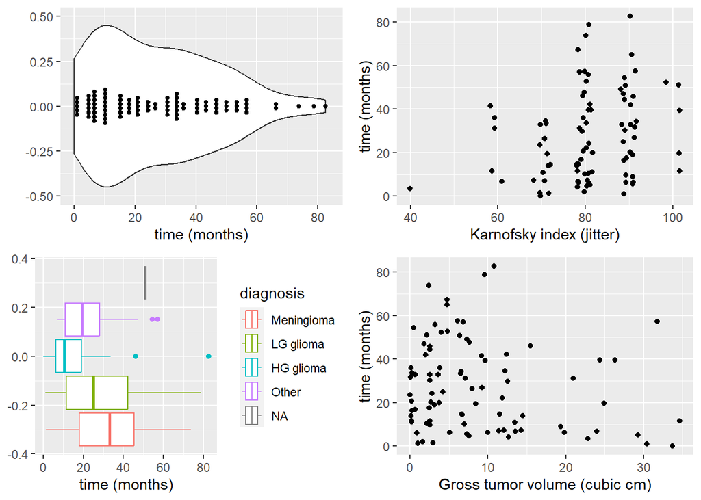

```r
bc <- BrainCancer %>% mutate(status = as.factor(status))

vp <- bc %>% ggplot(aes(x=time, y=rep(0,88))) +
  geom_violin() +
  geom_dotplot(stackdir = "center", dotsize = 0.5) +
  labs(x = "time (months)", y = "")

kip <- bc %>% ggplot(aes(x = jitter(ki), y = time)) +
  geom_point() +
  labs(x = "Karnofsky index (jitter)", y = "time (months)")

dip <- bc %>% ggplot(aes(x = time, color = diagnosis)) +
  geom_boxplot() +
  labs(x = "time (months)")

gtvp <- bc %>% ggplot(aes(x = gtv, y = time)) +
  geom_point() +
  labs(x = "Gross tumor volume (cubic cm)", y = "time (months)")

grid.arrange(vp, kip, dip, gtvp, ncol=2)
```

1. What do we see in these figure?
2. Which variable did we ignore here? (hint: type `? BrainCancer` and read about the varibles in the data set. )
3. By ignoring this variable identified in 2), what are some potential pitfalls that we may encounter?

### Censored data

To help with this issue, we introduce the idea of censored data. We suppose that we know the true *survival time*, $T$, as well as a true *censoring time*, $C$. The survival time represents the time at which the event of interest occurs: for instance, the time at which the patient dies, or the customer cancels his or her subscription. By contrast, the censoring time is the time at which censoring occurs: for example, the time at which the patient drops out of the study or the study ends.

We then define the random variable:
$$Y =
\min(T,C)$$

and the status indicator:
$$\delta =
\begin{cases} 1 \quad \text{ if } T\le C \\ 0 \quad \text{ if } T >
C. \end{cases}$$
where $\delta = 1$ indicates that we observe the true survival time and $\delta = 0$ indicates that we observe the censoring time. We record the $n$ observations as the pair $(Y, \delta)$, which we can denote as $(y_1, \delta_1), \ldots, (y_n, \delta_n)$.

4. Consider the following picture, representing $n=4$ patients for a 365-day follow up study after the cancer study. Write out the 4 observations using notation described above and describe what you are seeing:

[figure not shown]

5. Update the figures above to take into account the fact that some of the observations are censored. What do we see now?

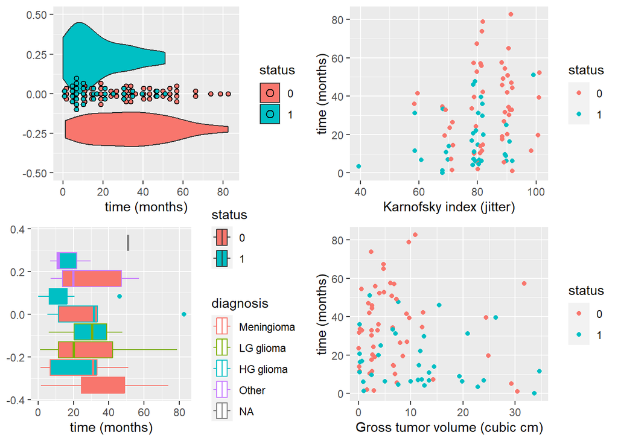

```r
vp2 <- bc %>% ggplot(aes(x=time, y=rep(0,88), fill=status)) +
  geom_violin() +
  geom_dotplot(aes(fill=status), stackdir = "center", dotsize = 0.95) +
  labs(x = "time (months)", y = "")

kip2 <- bc %>% ggplot(aes(x = jitter(ki), y = time, color=status)) +
  geom_point() +
  labs(x = "Karnofsky index (jitter)", y = "time (months)")

dip2 <- bc %>% ggplot(aes(x = time, color = diagnosis, fill=status)) +
  geom_boxplot() +
  labs(x = "time (months)")

gtvp2 <- bc %>% ggplot(aes(x = gtv, y = time, color=status)) +
  geom_point() +
  labs(x = "Gross tumor volume (cubic cm)", y = "time (months)")

grid.arrange(vp2, kip2, dip2, gtvp2, ncol=2)
```

### Kaplan-Meier Survival Curve

The survival curve or survival function is defined as
$$\begin{equation}
S(t) = P(T > t) \label{survfunc}
\end{equation}$$

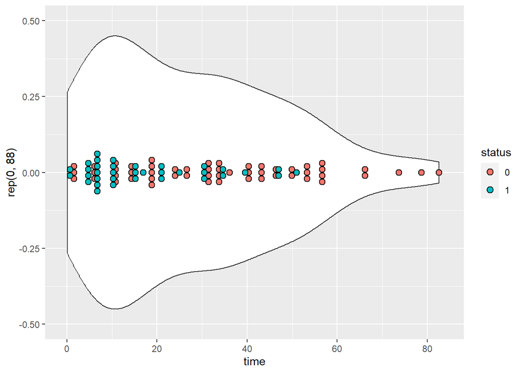

```r
bc <- BrainCancer %>% mutate(status = factor(status))

bc %>% ggplot(aes(x=time, y=rep(0,88))) + geom_violin() + geom_dotplot(aes(fill=status), stackdir = "center", dotsize = 0.5)
```

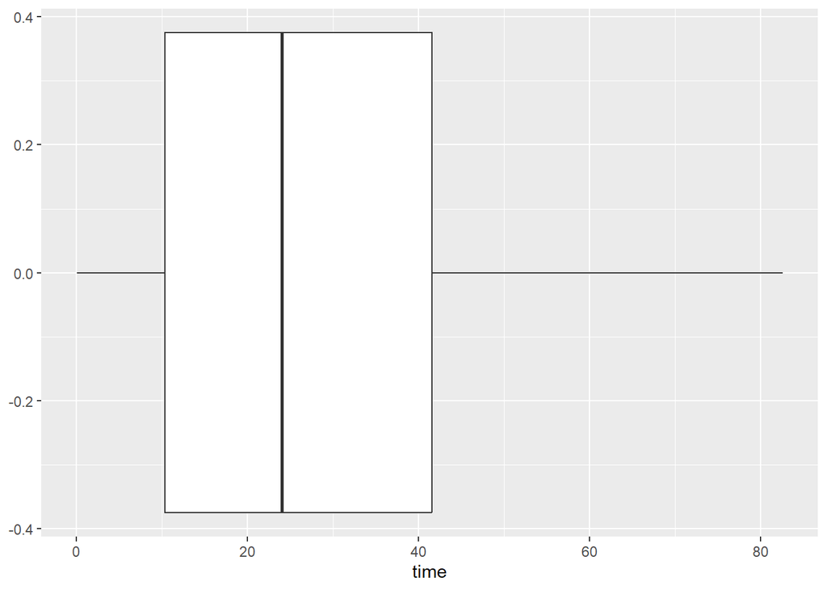

```r
bc %>% ggplot(aes(x=time)) + geom_boxplot()
```

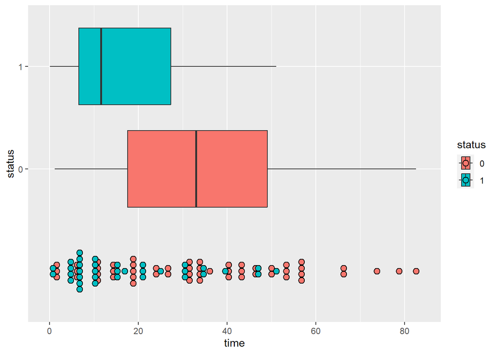

```r
bc %>% ggplot(aes(x = time, y = status, fill = status)) +
  geom_boxplot() +
  geom_dotplot(aes(y=status), stackdir = "center", dotsize = 0.5)
```